# Git Learning

HCZ

## Git工作流程

1.克隆 Git 资源作为工作目录。

2.在克隆的资源上添加或修改文件。

3.如果其他人修改了，你可以更新资源。

4.在提交前查看修改。

5.提交修改。

6.在修改完成后，如果发现错误，可以撤回提交并再次修改并提交。

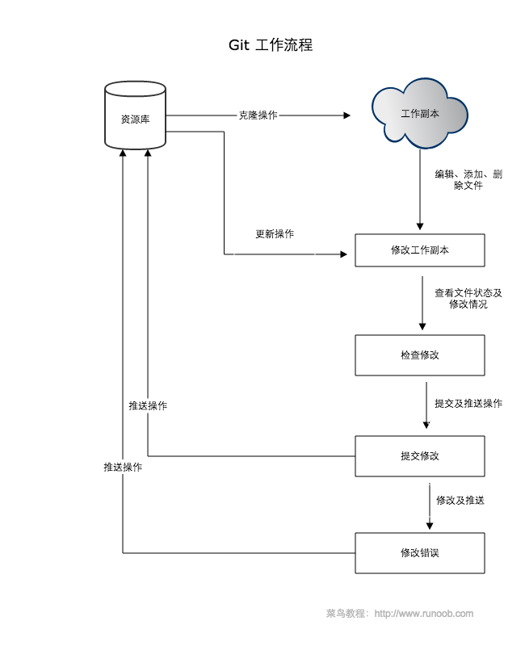

## Git基本概念

1.工作区：就是你在电脑里能看到的目录。

2.暂存区：英文叫stage或index。一般存放在“.git”目录下的“index”文件中，所以我们把暂存区有时也叫作索引(index)。

3.版本库：工作区有一个隐藏目录“.git”，这个不算工作区，而是Git的版本库。

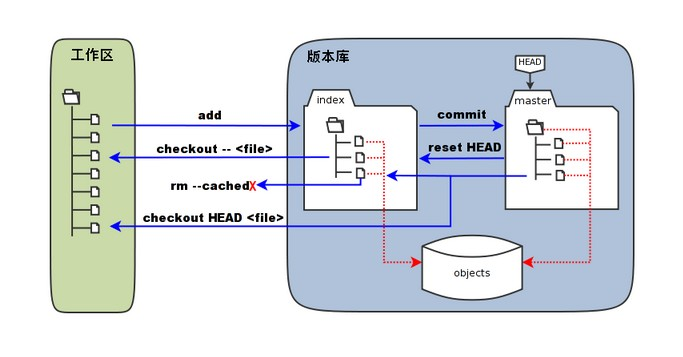

图中的指令： (1)**git add**:当对工作区修改（或新增）的文件执行“git add”命令时，暂存区的目录树被更新，同时工作区修改（或新增）的文件内容被写入到对象库中的一个新的对象中，而该对象的ID被记录在暂存区的文件索引中。 (2)**git commit**:当执行提交操作“git commit”时，暂存区的目录树写到版本库（对象库）中，master 分支会做相应的更新。即 master 指向的目录树就是提交时暂存区的目录树。 (3)**git reset HEAD**:当执行 git reset HEAD 命令时，暂存区的目录树会被重写，被 master 分支指向的目录树所替换，但是工作区不受影响。 (4)**git rm –cached** :当执行 git rm –cached 命令时，会直接从暂存区删除文件，工作区则不做出改变。 (5)**git checkout**:当执行 git checkout . 或者 git checkout – 命令时，会用暂存区全部或指定的文件替换工作区的文件。这个操作很危险，会清除工作区中未添加到暂存区中的改动。

## Git创建仓库

(1)**git init**:使用 git init 命令来初始化一个 Git 仓库，Git 的很多命令都需要在 Git 的仓库中运行，所以 git init 是使用 Git 的第一个命令。在执行完成 git init 命令后，Git 仓库会生成一个 .git 目录，该目录包含了资源的所有元数据，其他的项目目录保持不变。

(2)**git clone**:使用 git clone 从现有 Git 仓库中拷贝项目。

```
git clone <"repository name">
```

(3)**git config**:git 的设置使用 git config 命令。

## Git基本操作

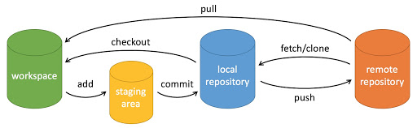

常用指令：git clone, git push, git add, git commit, git checkout, git pull.

**提交与修改操作** (1)git add: 添加文件到仓库或版本库。 (2)git status: 查看仓库当前状态，显示有变更的文件。 (3)git diff: 比较文件的不同，即暂存区和工作区的差异。 (4)git commit: 提交暂存区到本地仓库。 (5)git reset: 回退版本。 (6)git rm: 删除工作区文件。 (7)git mv: 移动或重命名工作区文件。 (8)git log: 查看历史提交记录。 (9)git blame : 以列表形式查看制定文件的历史修改记录。

**远程操作** (1)git remote: 远程仓库操作。 (2)git fetch: 从远程获取代码库。 (3)git pull: 下载远程代码并合并。 (4)git push: 上传远程代码并合并。

## 我的常用操作

### git add .

将工作区所有文件添加到版本库。

### git commit -m “remark”

提交暂存区到本地仓库。

### git remote -v

显示所有远程仓库及其链接。

### git push origin master

将文件推送到远程仓库origin的master分支。

### git push -u origin master

加了参数-u后，以后即可直接用git push 代替git push origin master。

### git push origin –delete master

删除远程仓库origin的master分支。

### git pull origin master –allow-unrelated-histories

将远程仓库的master分支与当前工作区分支合并。